# Regularização

Bruna Wundervald

## Regularização

- Quando utilizamos métodos de regressão, podemos nos deparar com bancos de dados que possuem muitas covariáveis em relação à quantidade de observações. Uma suposição que pode ser feita é a de que algumas dessas variáveis tem um alto poder de predição. Assim, um bom método para trabalhar com esse problema é **regular** a entrada de vairiáveis em um modelo, eliminando-as ou impondo pesos/penalidade nas entradas.
- A ideia de utilizar penalidades é aplicada através e **Multiplicadores de Lagrange**:

$$min_{\beta} \sum_{i = 1}^{n}\Big(y_i - \beta_0 - \sum_{j = 1}^{p}
\beta_j x_{ij} \Big)^{2} + \lambda P(\beta)$$

Onde $P(\beta)$ faz o papel de penalidade, mantendo as estimativas de $\beta_j$ perto de 0. Utilizando a família das potências, temos:

$$min_{\beta} \sum_{i = 1}^{n}\Big(y_i - \beta_0 - \sum_{j = 1}^{p}
\beta_j x_{ij} \Big)^{2} + \lambda \sum_{j = 1}^{p} |\beta_j|^q$$

Ou seja, quanto maior é o valor absoluto do coeficiente, mais penalidade é atribuída à ele. Consideramos $\lambda$ como o parâmetro de *tuning*.

### Penalização Ridge

- Neste caso, o objetivo é otimizar:

$$min_{\beta} \sum_{i = 1}^{n}\Big(y_i - \beta_0 - \sum_{j = 1}^{p}
\beta_j x_{ij} \Big)^{2} + \lambda \sum_{j = 1}^{p} \beta_j^2$$

- A ideia é somar uma constante $\lambda$ à diagonal da matriz se $p > n$, solucionando o problema da singularidade:

$$\hat \beta = (\mathbf X^T \mathbf X + \lambda \mathbf I)^{-1}
\mathbf X^T \mathbf y$$

Notar que $\hat \beta_{\lambda}^{R} = \frac{\hat \beta^{OLS}}{ 1 + \lambda}$, caracterizando algo importante na regressão *ridge*: o “encolhimento” dos parâmetros.

### Penalização Lasso

- Agora, o objetivo é otimizar:

$$min_{\beta} \sum_{i = 1}^{n}\Big(y_i - \beta_0 - \sum_{j = 1}^{p}
\beta_j x_{ij} \Big)^{2} + \lambda \sum_{j = 1}^{p} |\beta_j|$$

### Elastic Net

- A *Elastic Net* é basicamente a combinação entre os métodos *Lasso* e *Ridge*:

$$min_{\beta} \sum_{i = 1}^{n}\Big(y_i - \beta_0 - \sum_{j = 1}^{p}
\beta_j x_{ij} \Big)^{2} + \lambda \sum_{j = 1}^{p}
\Big(\alpha |\beta_j| + (1 - \alpha) \beta^{2}_j \Big)$$

### Selecionando $\lambda$ ótimo

- Assim como em outros métodos de *Machine Learning*, utiliza-se validação cruzada para encontrar um parâmetro ótimo, que neste caso é o $\lambda$. Os passos para isso são:
  1. Avaliar a taxa de erro de classificação para um certo *grid* de $\lambda$;
  2. Verificar qual dos $\lambda$ testados produz a menor taxa de erro;
  3. Ajustar o novo modelo com todas as observações e o $\lambda$ ótimo.

### Exemplos

```r
set.seed(20172)
# Carregamento de pacotes
library(tidyverse)
library(plyr)
library(dplyr)
library(glmnet)
library(glmnetUtils)

# Leitura e organização da base:
# 1. Leitura
# 2. Filtra apenas quem mora no centro e tem renda maior que 0
# 3. Seleciona apenas as colunas de interesse
# 4. Transforma algumas colunas em fator e decide quem fará parte da
# amostra de treino e da de teste

db <- read.csv("dados2.txt",
               header = TRUE,
               sep = "\t",
               encoding = "UTF-8") %>%
  filter(nom_localidade_fam == "CENTRO",
         vlr_renda_total_fam > 0) %>%
  dplyr::select(c(vlr_renda_total_fam,
                  qtd_comodos_domic_fam,    qtd_comodos_dormitorio_fam,
                  cod_material_piso_fam,    cod_material_domic_fam,
                  cod_agua_canalizada_fam,  cod_escoa_sanitario_domic_fam,
                  cod_iluminacao_domic_fam,
                  cod_calcamento_domic_fam,
                  qtd_pessoas_domic_fam,
                  val_desp_energia_fam, val_desp_agua_esgoto_fam,
                  val_desp_gas_fam, val_desp_alimentacao_fam,
                  val_desp_transpor_fam,    val_desp_aluguel_fam)) %>%
  dplyr::mutate(cod_material_domic_fam = factor(cod_material_domic_fam),
                cod_agua_canalizada_fam = factor(cod_agua_canalizada_fam),
                cod_calcamento_domic_fam = factor(cod_calcamento_domic_fam),
                cod_escoa_sanitario_domic_fam = factor(cod_escoa_sanitario_domic_fam),
                part = ifelse(runif(695) > 0.3, "treino", "teste"))
dim(db)
```

```
[1] 695  17
```

```r
#-------------------------------------------------------------
# Regressão Ridge
#-------------------------------------------------------------

# Amostra de treino
db.t <- db %>%
  filter(part == "treino") %>%
  dplyr::select(-c(part))

db.te <- db %>%
  filter(part == "teste") %>%
  dplyr::select(-c(part))

# Modelo linear simples
m0 <- lm(vlr_renda_total_fam ~ ., data = db.t)
summary(m0)
```

```
Call:
lm(formula = vlr_renda_total_fam ~ ., data = db.t)

Residuals:
    Min      1Q  Median      3Q     Max
-1562.4  -445.1   -62.6   300.9  4945.4

Coefficients:
                                 Estimate Std. Error t value Pr(>|t|)
(Intercept)                    -228.51143  222.65542  -1.026 0.305320
qtd_comodos_domic_fam           184.54097   26.54753   6.951 1.33e-11 ***
qtd_comodos_dormitorio_fam     -199.46653   56.49227  -3.531 0.000458 ***
cod_material_piso_fam            64.44493   32.38802   1.990 0.047241 *
cod_material_domic_fam2         753.44908  232.85016   3.236 0.001306 **
cod_material_domic_fam3          76.72224   85.31339   0.899 0.368991
cod_material_domic_fam6          26.84502  203.85007   0.132 0.895290
cod_agua_canalizada_fam2         31.56261  673.89693   0.047 0.962665
cod_escoa_sanitario_domic_fam2 -225.04918  401.64024  -0.560 0.575546
cod_escoa_sanitario_domic_fam6 -174.23231  514.77612  -0.338 0.735178
cod_iluminacao_domic_fam       -195.68158   84.27931  -2.322 0.020704 *
cod_calcamento_domic_fam2       278.71042  166.66672   1.672 0.095192 .
cod_calcamento_domic_fam3        63.56178  257.15809   0.247 0.804893
qtd_pessoas_domic_fam            -0.07274   28.57232  -0.003 0.997970
val_desp_energia_fam              1.36104    0.65327   2.083 0.037796 *
val_desp_agua_esgoto_fam         -0.52575    0.83514  -0.630 0.529328
val_desp_gas_fam                 -0.99182    2.08865  -0.475 0.635125
val_desp_alimentacao_fam          1.85294    0.21553   8.597  < 2e-16 ***
val_desp_transpor_fam             1.41330    0.66910   2.112 0.035236 *
val_desp_aluguel_fam              0.02905    0.11402   0.255 0.799007
---
Signif. codes:  0 '***' 0.001 '**' 0.01 '*' 0.05 '.' 0.1 ' ' 1

Residual standard error: 666.7 on 435 degrees of freedom
  (5 observations deleted due to missingness)
Multiple R-squared:  0.3373,    Adjusted R-squared:  0.3084
F-statistic: 11.65 on 19 and 435 DF,  p-value: < 2.2e-16
```

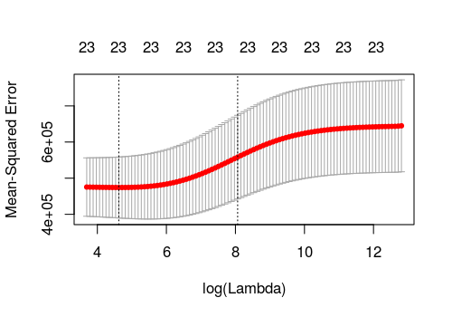

```r
# Aqui, existem evidências a favor da não nulidade dos coecientes
# para 'qtd_comodos_domic_fam', 'qtd_comodos_dormitorio_fam',
# 'cod_material_domic_fam', 'val_desp_energia_fam' e
# 'val_desp_alimentacao_fam'

# Ridge
m0.r <- glmnetUtils::cv.glmnet(vlr_renda_total_fam ~ .,
                               data = db.t,
                                   alpha = 0)

plot(m0.r)
```

```r
# O melhor valor de lambda:
m0.r$lambda.1se
```

```
[1] 3179.415
```